# The Path to Path Enlightenment

## R Graphics: The painters model

R graphics follows a “painters model”: when we draw a shape, it is drawn over the top of previous drawing. For example, the following code draws a circle followed by a rectangle. Both shapes have an opaque border, but a semitransparent fill, which allows us to see that the rectangle is drawn on top of the circle.

```r
library(grid)
```

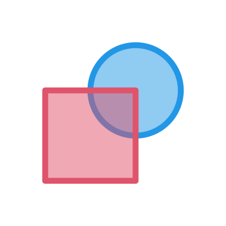

```r
grid.circle(.6, .6, r=.2,
            gp=gpar(col=4, lwd=5, fill=adjustcolor(4, alpha=.5)))
grid.rect(.4, .4, width=.4, height=.4,
          gp=gpar(col=2, lwd=5, fill=adjustcolor(2, alpha=.5)))
```

## Graphics devices: Paths

R graphics output is sent to a *graphics device* either to draw to the screen, or to record the drawing in a file. For example, the `postscript()` device records drawing in a PostScript file.

The painters model means that a graphics devices is only asked to draw one shape at a time, e.g., draw a circle *then* draw a rectangle. For example, the PostScript to draw a circle and a rectangle could look like the following. The important part of the code is the clear separation into two shapes, each starting with a `newpath` and ending with a `fill` (to fill the shape).

```
%%BoundingBox: 0 0 200 200

newpath
120 120 40 360 0 arcn
.13 .59 .90 setrgbcolor
fill

newpath
 40  40 moveto
 40 120 lineto
120 120 lineto
120  40 lineto
closepath
.87 .33 .42 setrgbcolor
fill

showpage
```

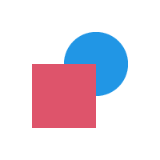

However, many graphics devices support a more sophisticated drawing model based on *paths*. In this model, a single path can be constructed from more than on shape. For example, the PostScript code below draws the same two shapes as before, but draws them within a single path (and then fills that single path).

```
%%BoundingBox: 0 0 200 200

newpath
120 120 40 360 0 arcn
 40  40 moveto
 40 120 lineto
120 120 lineto
120  40 lineto
closepath
.87 .33 .42 setrgbcolor
fill

showpage
```

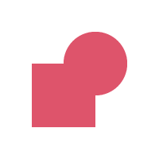

The result in this case is a single shape that is the union of the two individual shapes. We can get even fancier results by controlling how “inside” of the path is interpreted. For example, the following PostScript code creates exactly the same single path from the two shapes, but this time runs `eofill` (rather than `fill`). That changes to an “even-odd” fill rule (from the default “non-zero winding” rule), so the overlap between the two shapes within the path is now “outside” the overall path and we get a shape with a hole in it.

```
%%BoundingBox: 0 0 200 200

newpath
120 120 40 360 0 arcn
 40  40 moveto
 40 120 lineto
120 120 lineto
120  40 lineto
closepath
.87 .33 .42 setrgbcolor
eofill

showpage
```

[figure not shown]

Another element of the more sophisticated path-drawing model is the ability to construct a path from Bezier curves. For example, the following PostScript code describes a path from a series of straight lines and Bezier curves.

```
%%BoundingBox: 0 0 200 200

newpath
 40  40 moveto
 40 120 lineto
 80 120  80 120  80 160 curveto
160 160 lineto
160  80 lineto
120  80 120  80 120  40 curveto
closepath
.87 .33 .42 setrgbcolor
eofill

showpage
```

[figure not shown]

## R-paths

R provides functions to draw more complex shapes, that it calls “paths”. However, we will refer to these as *R-paths* because they are not as sophisticated as the paths available on some graphics devices.

The following code draws the R version of the combination of circle and rectangle with a hole where they overlap.

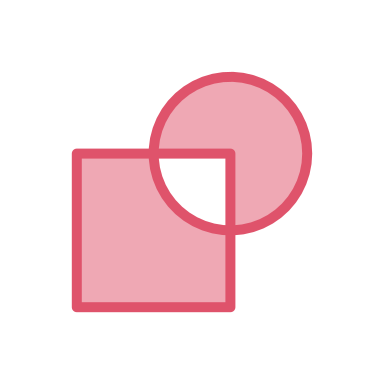

```r
circle <- function(x, y, r) {
    t <- seq(0, 2*pi, length.out=50)
    list(x=x + r*cos(t), y=y + r*sin(t))
}
c <- circle(.6, .6, .2)
grid.path(c(c$x, .2, .2, .6, .6),
          c(c$y, .2, .6, .6, .2),
          id.lengths=c(50, 4), rule="evenodd",
          gp=gpar(col=2, lwd=5, fill=adjustcolor(2, alpha=.5)))
```

Although this shows that *some* aspects of real paths are available in R graphics, there are some limitations:

- We cannot construct the path from shapes; we have to generate a series of points along the outline of the path ourselves (e.g., the `circle()` function above).
- We cannot construct a path from curves. Even though it is possible to draw a stand-alone Bezier curve (e.g., with the ‘gridBezier’ package), we cannot build a path by adding a Bezier curve to other shapes. Furthermore, R graphics never asks a graphics device to draw a curve; it draws curves by drawing lots of short straight lines that approximate the curve.

## Clipping paths

The addition of clipping paths to the graphics engine actually creates situation where we can *accidentally* access some of the more sophisticated path functionality of some graphics devices.

## Caveats

Note that there *are* a couple of ways that we can generate a more sophisticated path by combining simple shapes in R graphics

- The `grid::grobCoords()` function.
- The ‘gridGeometry’ package.